# Probability and Statistics HW 3

S Richard Smith

February 25, 2016

# Practice

## Q3.21 Married Women

> The 2010 American Community Survey estimates that 47.1% of women ages 15 years and over are married.

The above sounds like it would be a binomial distributijon. But first, let’s compare it against the qualifying attributes:

#### 1. The trials are independent.

This qualification is met since the respondents are randomly chosen.

#### 2. The number of trials, n, is fixed.

The number of trials is discrete and defined as 3.

#### 3. Each trial outcome can be classified as a success or failure.

There are 2 possible outcomes only for each “trial.” Married or unmarried.

#### 4. The probability of a success, p, is the same for each trial.

The probability of marriage (success) is given by the survey as 47.1%.

Therefore, we do have a binomial distribution.

### (a) We randomly select three women between these ages. What is the probability that the third woman selected is the only one who is married?

Because we know that these women were randomly selected, we know that each “trial” is independent. Given that, the probability of randomly selecting 2 unmarried women and then a married woman would be the product of the probability of each event.

$P(A_1) \times P(A_2) \times ... \times P(A_k)$

$P(U) \times P(U) \times P(M)$

$0.529^2 \times .471 =$

```r
Pm <- 0.471
UUM <- (1-Pm)^2*Pm
UUM
```

```
## [1] 0.1318051
```

### (b) What is the probability that all three randomly selected women are married?

As above, we know we must take the probability of randomly selecting 3 married women and multiply them together.

$P(A_1) \times P(A_2) \times ... \times P(A_k)$

The probability of A is 47.1%. *k*

$.471 \times .471 \times .471 = .471^3 =$ 0.1044871

### (c) On average, how many women would you expect to sample before selecting a married woman? What is the standard deviation?

$(1-p)^{n-1}p$ $p = .471$ $\mu = \frac{1}{p}$ $\mu = \frac{1}{.471}$

```r
MeanWait <- 1/Pm
MeanWait
```

```
## [1] 2.123142
```

${\sigma}^2= \frac{1-p}{p^2}$ ${\sigma}^2= \frac{1-.471}{.471^2}$

```r
Avgwait <- sqrt((1-Pm)/Pm^2)
Avgwait
```

```
## [1] 1.544212
```

We can see this illustrated by taking a random sample (of 300 tests) to see how long it takes us to encounter a married woman.

```r
sample <- rgeom(300, prob = .471)
summary(sample)
```

```
##    Min. 1st Qu.  Median    Mean 3rd Qu.    Max.
##   0.000   0.000   1.000   1.123   2.000   9.000
```

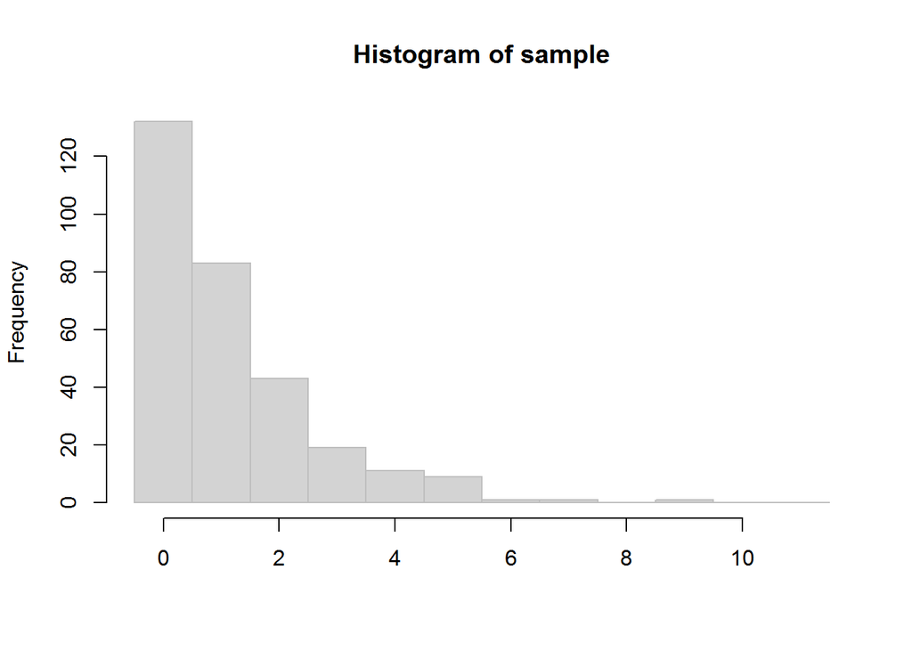

```r
hist(sample, breaks=seq(-0.5,12,1), col='light grey', border='grey', xlab = '')
```

4. If the proportion of married women was actually 30%, how many women would you expect to sample before selecting a married woman? What is the standard deviation?

If the probability of being married changes, we can simply insert that and run the calculations again.

$(1-p)^{n-1}p$ $p = .30$ $\mu = \frac{1}{p}$ $\mu = \frac{1}{.30}$

```r
Pm <- .3
MeanWait <- 1/Pm
MeanWait
```

```
## [1] 3.333333
```

```r
Avgwait <- sqrt((1-Pm)/Pm^2)
Avgwait
```

```
## [1] 2.788867
```

5. Based on your answers to parts (c) and (d), how does decreasing the probability of an event affect the mean and standard deviation of the wait time until success?

As we can see from (c) and (d) above, there is an inverse relationship between the probability and the expected wait time until success (or mean). This makes intuitive sense: the less likely something is to be a success (e.g., winning the lottery), the longer you have to wait, or the more trials that will be necessary before success.